# RFM analysis script

#PART 1. DATA LOADING AND EXPLORATORY ANALYSIS / ЗАГРУЗКА И РАЗВЕДОЧНЫЙ АНАЛИЗ ДАННЫХ

##1. Loading libraries and studying data structure / Загрузка библиотек и изучение структуры данных

```r
library(tidyverse)
```

```r
library(ggplot2)
library(readxl)
salesdata <- read_excel("data/Sales_Data.xlsx")
head(salesdata)
```

```
## # A tibble: 6 × 8
##   InvoiceNo StockCode Description         Quantity InvoiceDate         UnitPrice
##   <chr>     <chr>     <chr>                  <dbl> <dttm>                  <dbl>
## 1 536365    85123A    WHITE HANGING HEAR…        6 2010-12-01 08:26:00      2.55
## 2 536365    71053     WHITE METAL LANTERN        6 2010-12-01 08:26:00      3.39
## 3 536365    84406B    CREAM CUPID HEARTS…        8 2010-12-01 08:26:00      2.75
## 4 536365    84029G    KNITTED UNION FLAG…        6 2010-12-01 08:26:00      3.39
## 5 536365    84029E    RED WOOLLY HOTTIE …        6 2010-12-01 08:26:00      3.39
## 6 536365    22752     SET 7 BABUSHKA NES…        2 2010-12-01 08:26:00      7.65
## # ℹ 2 more variables: CustomerID <dbl>, Country <chr>
```

```r
str(salesdata) #studying the structure / изучаем структуру
```

```
## tibble [541,909 × 8] (S3: tbl_df/tbl/data.frame)
##  $ InvoiceNo  : chr [1:541909] "536365" "536365" "536365" "536365" ...
##  $ StockCode  : chr [1:541909] "85123A" "71053" "84406B" "84029G" ...
##  $ Description: chr [1:541909] "WHITE HANGING HEART T-LIGHT HOLDER" "WHITE METAL LANTERN" "CREAM CUPID HEARTS COAT HANGER" "KNITTED UNION FLAG HOT WATER BOTTLE" ...
##  $ Quantity   : num [1:541909] 6 6 8 6 6 2 6 6 6 32 ...
##  $ InvoiceDate: POSIXct[1:541909], format: "2010-12-01 08:26:00" "2010-12-01 08:26:00" ...
##  $ UnitPrice  : num [1:541909] 2.55 3.39 2.75 3.39 3.39 7.65 4.25 1.85 1.85 1.69 ...
##  $ CustomerID : num [1:541909] 17850 17850 17850 17850 17850 ...
##  $ Country    : chr [1:541909] "United Kingdom" "United Kingdom" "United Kingdom" "United Kingdom" ...
```

##2. Any NAs? / Пропуски в данных

```r
colSums(is.na(salesdata))
```

```
##   InvoiceNo   StockCode Description    Quantity InvoiceDate   UnitPrice
##           0           0        1454           0           0           0
##  CustomerID     Country
##      135080           0
```

```r
salesdata %>%
  summarise(across(everything(), ~sum(is.na(.)) / n() * 100)) %>%
  pivot_longer(everything(), names_to = "Column", values_to = "Percent_Missing") %>%
  arrange(desc(Percent_Missing))
```

```
## # A tibble: 8 × 2
##   Column      Percent_Missing
##   <chr>                 <dbl>
## 1 CustomerID           24.9
## 2 Description           0.268
## 3 InvoiceNo             0
## 4 StockCode             0
## 5 Quantity              0
## 6 InvoiceDate           0
## 7 UnitPrice             0
## 8 Country               0
```

```r
#all variables but Customer ID are fine, we don't know the authorisation of circa 25% of all operations / все переменные кроме номера клиента в порядке, мы не знаем клиентов у четверти сделок
```

##3. Descriptive statistics / Описательная статистика

```r
salesdata %>%
  select(where(is.numeric)) %>%
  summary()
```

```
##     Quantity           UnitPrice           CustomerID
##  Min.   :-80995.00   Min.   :-11062.06   Min.   :12346
##  1st Qu.:     1.00   1st Qu.:     1.25   1st Qu.:13953
##  Median :     3.00   Median :     2.08   Median :15152
##  Mean   :     9.55   Mean   :     4.61   Mean   :15288
##  3rd Qu.:    10.00   3rd Qu.:     4.13   3rd Qu.:16791
##  Max.   : 80995.00   Max.   : 38970.00   Max.   :18287
##                                          NA's   :135080
```

##4. Unique values / Уникальные значения

```r
#number of unique customers / число уникальных клиентов
cat("Number of unique customers")
```

```
## Number of unique customers
```

```r
salesdata %>%
  filter(!is.na(CustomerID)) %>%
  summarise(Unique_Customers = n_distinct(CustomerID))
```

```
## # A tibble: 1 × 1
##   Unique_Customers
##              <int>
## 1             4372
```

```r
#number of unique countries / число уникальных стран
salesdata %>%
  summarise(Unique_Countries = n_distinct(Country))
```

```
## # A tibble: 1 × 1
##   Unique_Countries
##              <int>
## 1               38
```

```r
#top 5 countries by the number of transactions / топ 5 стран по числу транзакций
salesdata %>%
  count(Country, sort = TRUE) %>%
  head(5)
```

```
## # A tibble: 5 × 2
##   Country             n
##   <chr>           <int>
## 1 United Kingdom 495478
## 2 Germany          9495
## 3 France           8557
## 4 EIRE             8196
## 5 Spain            2533
```

##5. Checking the date range / Проверяем диапазон по датам

```r
salesdata %>%
  summarise(
    Min_Date = min(InvoiceDate, na.rm = TRUE),
    Max_Date = max(InvoiceDate, na.rm = TRUE))
```

```
## # A tibble: 1 × 2
##   Min_Date            Max_Date
##   <dttm>              <dttm>
## 1 2010-12-01 08:26:00 2011-12-09 12:50:00
```

```r
#data covers the whole year history of transactions / Данные покрывают годовую историю транзакций
```

#PART 2. DATA CLEANING / ОЧИСТКА ДАННЫХ

##1. Removing NAs, negative price and quantities / Убираем все лишнее

```r
cleandf <- salesdata %>%
  filter(!is.na(CustomerID)) %>% #only known customers / только известные клиенты
  filter(Quantity > 0) %>% #only positive quantity / только положительные значения количества
  filter(UnitPrice > 0) %>% #only positive price / только положительные значения цены
  mutate(TotalPrice = Quantity * UnitPrice) #creating variable for price of purchase / переменная для суммы покупок

glimpse(cleandf)
```

```
## Rows: 397,884
## Columns: 9
## $ InvoiceNo   <chr> "536365", "536365", "536365", "536365", "536365", "536365"…
## $ StockCode   <chr> "85123A", "71053", "84406B", "84029G", "84029E", "22752", …
## $ Description <chr> "WHITE HANGING HEART T-LIGHT HOLDER", "WHITE METAL LANTERN…
## $ Quantity    <dbl> 6, 6, 8, 6, 6, 2, 6, 6, 6, 32, 6, 6, 8, 6, 6, 3, 2, 3, 3, …
## $ InvoiceDate <dttm> 2010-12-01 08:26:00, 2010-12-01 08:26:00, 2010-12-01 08:2…
## $ UnitPrice   <dbl> 2.55, 3.39, 2.75, 3.39, 3.39, 7.65, 4.25, 1.85, 1.85, 1.69…
## $ CustomerID  <dbl> 17850, 17850, 17850, 17850, 17850, 17850, 17850, 17850, 17…
## $ Country     <chr> "United Kingdom", "United Kingdom", "United Kingdom", "Uni…
## $ TotalPrice  <dbl> 15.30, 20.34, 22.00, 20.34, 20.34, 15.30, 25.50, 11.10, 11…
```

```r
summary(cleandf$Quantity)
```

```
##     Min.  1st Qu.   Median     Mean  3rd Qu.     Max.
##     1.00     2.00     6.00    12.99    12.00 80995.00
```

```r
summary(cleandf$UnitPrice) #everything fine / всё ок
```

```
##     Min.  1st Qu.   Median     Mean  3rd Qu.     Max.
##    0.001    1.250    1.950    3.116    3.750 8142.750
```

##2. Creating RFM metrics - Recency, Frequency, Monetary / Создаём RFM метрики - давность, частота, деньги

```r
snapshot_date <- max(cleandf$InvoiceDate) + days(1) #creating the date of snapshot for future calculations / делаем дату среза данных

rfm <- cleandf %>%
  group_by(CustomerID) %>%
  summarise(
    Recency   = as.numeric(snapshot_date - max(InvoiceDate), units = "days"),
    Frequency = n_distinct(InvoiceNo),
    Monetary  = sum(TotalPrice)
  ) %>%
  ungroup()

glimpse(rfm) #structure of RFM frame / структура RFM фрейма
```

```
## Rows: 4,338
## Columns: 4
## $ CustomerID <dbl> 12346, 12347, 12348, 12349, 12350, 12352, 12353, 12354, 123…
## $ Recency    <dbl> 326.117361, 2.873611, 75.984028, 19.124306, 310.867361, 36.…
## $ Frequency  <int> 1, 7, 4, 1, 1, 8, 1, 1, 1, 3, 1, 2, 4, 3, 1, 10, 2, 4, 2, 1…
## $ Monetary   <dbl> 77183.60, 4310.00, 1797.24, 1757.55, 334.40, 2506.04, 89.00…
```

```r
summary(rfm) #descriptive statistics for RFM / описательная статистика для RFM
```

```
##    CustomerID       Recency         Frequency          Monetary
##  Min.   :12346   Min.   :  1.00   Min.   :  1.000   Min.   :     3.75
##  1st Qu.:13813   1st Qu.: 18.07   1st Qu.:  1.000   1st Qu.:   307.42
##  Median :15300   Median : 51.09   Median :  2.000   Median :   674.48
##  Mean   :15300   Mean   : 93.05   Mean   :  4.272   Mean   :  2054.27
##  3rd Qu.:16779   3rd Qu.:142.73   3rd Qu.:  5.000   3rd Qu.:  1661.74
##  Max.   :18287   Max.   :374.12   Max.   :209.000   Max.   :280206.02
```

```r
head(rfm) #first 6 clients / первые 6 клиентов
```

```
## # A tibble: 6 × 4
##   CustomerID Recency Frequency Monetary
##        <dbl>   <dbl>     <int>    <dbl>
## 1      12346  326.           1   77184.
## 2      12347    2.87         7    4310
## 3      12348   76.0          4    1797.
## 4      12349   19.1          1    1758.
## 5      12350  311.           1     334.
## 6      12352   36.9          8    2506.
```

#PART 3. RFM analysis / RFM анализ ##1. Assigning RFM scores by quantiles / Присваиваем RFM значения

```r
#quantile borders for control / делим на квантили
quantile(rfm$Recency,  probs = seq(0, 1, 0.2))
```

```
##        0%       20%       40%       60%       80%      100%
##   1.00000  13.79819  33.04694  72.06139 179.89792 374.12292
```

```r
quantile(rfm$Frequency, probs = seq(0, 1, 0.2))
```

```
##   0%  20%  40%  60%  80% 100%
##    1    1    2    3    6  209
```

```r
quantile(rfm$Monetary,  probs = seq(0, 1, 0.2))
```

```
##         0%        20%        40%        60%        80%       100%
##      3.750    250.194    490.096    942.276   2058.426 280206.020
```

```r
#NB! For Recency lower = better, so we reverse the values / для давности чем ниже, тем лучше, так что переворачиваем шкалу
rfm <- rfm %>%
  mutate(
    R_Score = ntile(-Recency, 5), #reverse the sign / меняем знак
    F_Score = ntile(Frequency, 5),
    M_Score = ntile(Monetary, 5))

#general RFM score /общее значение для RFM
rfm <- rfm %>%
  mutate(
    RFM_Sum  = R_Score + F_Score + M_Score,
    RFM_Code = paste0(R_Score, F_Score, M_Score)  #e.g. "555" or "344"
  )

glimpse(rfm) #every single change applied / всё ок
```

```
## Rows: 4,338
## Columns: 9
## $ CustomerID <dbl> 12346, 12347, 12348, 12349, 12350, 12352, 12353, 12354, 123…
## $ Recency    <dbl> 326.117361, 2.873611, 75.984028, 19.124306, 310.867361, 36.…
## $ Frequency  <int> 1, 7, 4, 1, 1, 8, 1, 1, 1, 3, 1, 2, 4, 3, 1, 10, 2, 4, 2, 1…
## $ Monetary   <dbl> 77183.60, 4310.00, 1797.24, 1757.55, 334.40, 2506.04, 89.00…
## $ R_Score    <int> 1, 5, 2, 4, 1, 3, 1, 1, 1, 4, 3, 5, 3, 3, 1, 5, 2, 5, 1, 5,…
## $ F_Score    <int> 1, 5, 4, 1, 1, 5, 1, 1, 1, 3, 1, 2, 4, 3, 1, 5, 2, 4, 2, 1,…
## $ M_Score    <int> 5, 5, 4, 4, 2, 5, 1, 4, 2, 5, 5, 4, 5, 5, 1, 5, 3, 4, 3, 1,…
## $ RFM_Sum    <int> 7, 15, 10, 9, 4, 13, 3, 6, 4, 12, 9, 11, 12, 11, 3, 15, 7, …
## $ RFM_Code   <chr> "115", "555", "244", "414", "112", "355", "111", "114", "11…
```

```r
summary(rfm[, c("R_Score", "F_Score", "M_Score", "RFM_Sum")]) #every value is ranged from 1 to 5 / каждое значение проранжировано от 1 до 5
```

```
##     R_Score         F_Score         M_Score         RFM_Sum
##  Min.   :1.000   Min.   :1.000   Min.   :1.000   Min.   : 3.000
##  1st Qu.:2.000   1st Qu.:2.000   1st Qu.:2.000   1st Qu.: 6.000
##  Median :3.000   Median :3.000   Median :3.000   Median : 9.000
##  Mean   :2.999   Mean   :2.999   Mean   :2.999   Mean   : 8.998
##  3rd Qu.:4.000   3rd Qu.:4.000   3rd Qu.:4.000   3rd Qu.:12.000
##  Max.   :5.000   Max.   :5.000   Max.   :5.000   Max.   :15.000
```

```r
head(rfm, 10) #first 10 entries / первые 10 строк
```

```
## # A tibble: 10 × 9
##    CustomerID Recency Frequency Monetary R_Score F_Score M_Score RFM_Sum
##         <dbl>   <dbl>     <int>    <dbl>   <int>   <int>   <int>   <int>
##  1      12346  326.           1   77184.       1       1       5       7
##  2      12347    2.87         7    4310        5       5       5      15
##  3      12348   76.0          4    1797.       2       4       4      10
##  4      12349   19.1          1    1758.       4       1       4       9
##  5      12350  311.           1     334.       1       1       2       4
##  6      12352   36.9          8    2506.       3       5       5      13
##  7      12353  205.           1      89        1       1       1       3
##  8      12354  233.           1    1079.       1       1       4       6
##  9      12355  215.           1     459.       1       1       2       4
## 10      12356   23.2          3    2811.       4       3       5      12
## # ℹ 1 more variable: RFM_Code <chr>
```

##2. Creating business segments for customers / Создаем сегменты для клиентов

```r
rfm <- rfm %>%
  mutate(
    Segment = case_when(
      #Champions: high R, F, M - best clients / ВИП клиенты
      R_Score >= 4 & F_Score >= 4 & M_Score >= 4 ~ "Champions",
      #Loyal Customers: high F and M, any R / Лояльные клиенты
      F_Score >= 4 & M_Score >= 4 ~ "Loyal Customers",
      #Potential Loyalists: high R (recent purchase), medium F/M / Потенциальные лояльные клиенты
      R_Score >= 4 & F_Score >= 2 & M_Score >= 2 ~ "Potential Loyalists",
      #New Customers: high R, low F and M (recent purchase, not much) / Новые клиенты
      R_Score >= 4 & F_Score <= 2 & M_Score <= 2 ~ "New Customers",
      #Promising: medium R, F, M, may become loyal /Обещающие клиенты
      R_Score >= 3 & F_Score >= 2 & M_Score >= 2 ~ "Promising",
      #At Risk: low R (did not buy anything for a while but were active previously) / в зоне риска
      R_Score <= 2 & F_Score >= 3 & M_Score >= 3 ~ "At Risk",
      #Cannot Lose Them: low R, but high F/M (leaving VIP) / уходящие ВИПы
      R_Score <= 2 & F_Score >= 4 & M_Score >= 4 ~ "Cannot Lose Them",
      #Hibernating: low R, medium F/M / спящие
      R_Score <= 2 & F_Score >= 2 ~ "Hibernating",
      #Lost: low R, F, M (gone) / потерянные
      R_Score <= 2 & F_Score <= 2 & M_Score <= 2 ~ "Lost",
      #Others / другие
      TRUE ~ "Others"))

#Check allocation of segments / проверяем распределение по сегментам
rfm %>%
  count(Segment, sort = TRUE) %>%
  mutate(Percent = n / sum(n) * 100)
```

```
## # A tibble: 9 × 3
##   Segment                 n Percent
##   <chr>               <int>   <dbl>
## 1 Champions             946   21.8
## 2 Hibernating           704   16.2
## 3 Potential Loyalists   559   12.9
## 4 Lost                  455   10.5
## 5 Others                429    9.89
## 6 Loyal Customers       416    9.59
## 7 Promising             366    8.44
## 8 At Risk               293    6.75
## 9 New Customers         170    3.92
```

#PART 4. Immediate visualisation / Визуализация ##1. Segment allocation / Распределение по сегментам

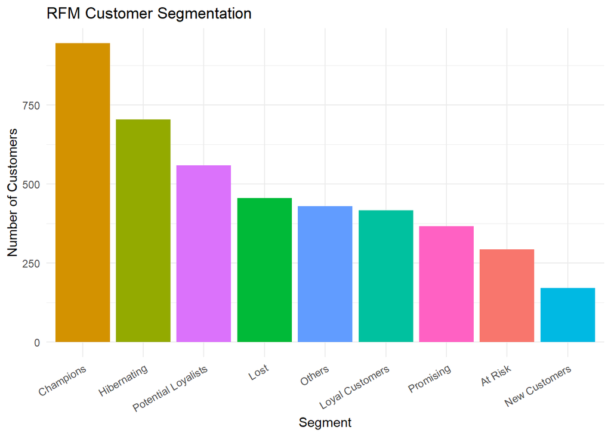

```r
seg_counts <- rfm %>%
  count(Segment, sort = TRUE)

ggplot(seg_counts, aes(x = reorder(Segment, -n), y = n, fill = Segment)) +
  geom_col(show.legend = FALSE) +
  labs(
    title = "RFM Customer Segmentation",
    x = "Segment",
    y = "Number of Customers"
  ) +
  theme_minimal() +
  theme(axis.text.x = element_text(angle = 30, hjust = 1))
```

##2. Average R/F/M by segments (heatmap) / Средние значения сегментов по R/F/M (тепловая карта)

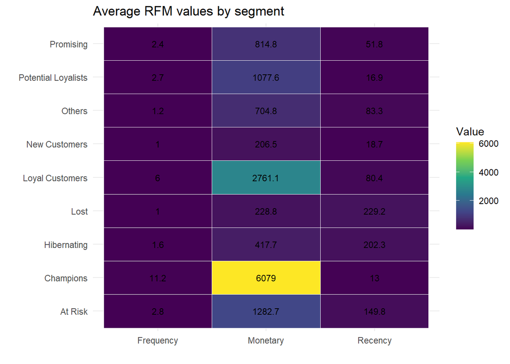

```r
seg_summary <- rfm %>%
  group_by(Segment) %>%
  summarise(
    Recency   = mean(Recency),
    Frequency = mean(Frequency),
    Monetary  = mean(Monetary),
    .groups = "drop"
  )

seg_long <- seg_summary %>%
  pivot_longer(cols = c(Recency, Frequency, Monetary),
               names_to = "Metric", values_to = "Value")

ggplot(seg_long, aes(x = Metric, y = Segment, fill = Value)) +
  geom_tile(color = "white") +
  geom_text(aes(label = round(Value, 1)), color = "black", size = 3) +
  scale_fill_viridis_c() +
  labs(
    title = "Average RFM values by segment",
    x = "",
    y = "") +
  theme_minimal()
```

Unclear image, the outlier affects the whole visualisation, need to sepate graphs for R, F and M Непонятный график, нужно разделить значения

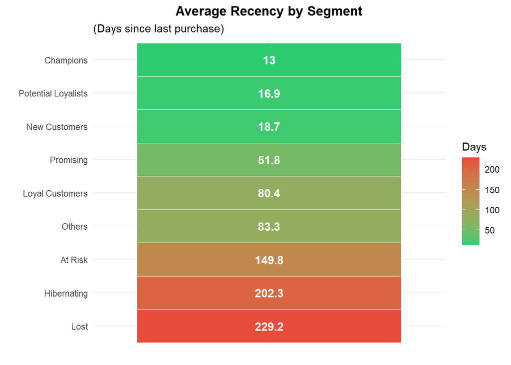

```r
#Recency heatmap
seg_recency <- rfm %>%
  group_by(Segment) %>%
  summarise(Recency = mean(Recency), .groups = "drop") %>%
  arrange(Recency)

rgr <- ggplot(seg_recency, aes(x = "", y = reorder(Segment, -Recency), fill = Recency)) +
  geom_tile(color = "white", width = 0.9) +
  geom_text(aes(label = round(Recency, 1)), color = "white", size = 4, fontface = "bold") +
  scale_fill_gradient(low = "#2ecc71", high = "#e74c3c") +  # for recent green to latest red
  labs(
    title = "Average Recency by Segment",
    subtitle = "(Days since last purchase)",
    x = "",
    y = "",
    fill = "Days") +
  theme_minimal() +
  theme(
    axis.text.x = element_blank(),
    plot.title = element_text(hjust = 0.5, face = "bold"))
rgr
```

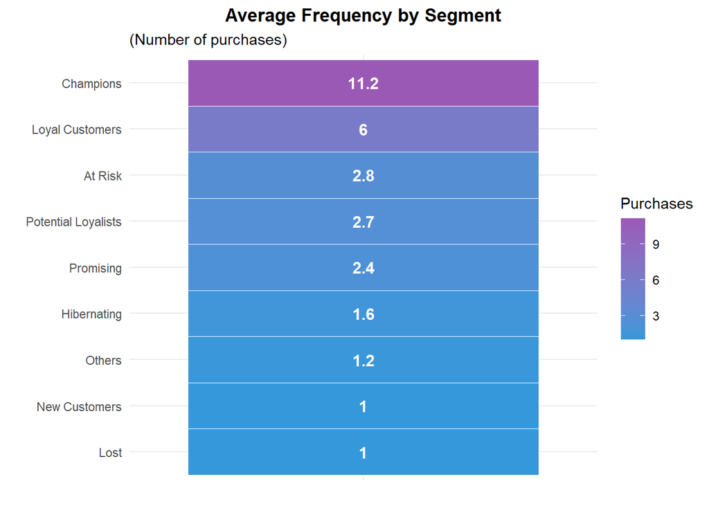

```r
#Frequency heatmap
seg_frequency <- rfm %>%
  group_by(Segment) %>%
  summarise(Frequency = mean(Frequency), .groups = "drop") %>%
  arrange(Frequency)

fgr <- ggplot(seg_frequency, aes(x = "", y = reorder(Segment, Frequency), fill = Frequency)) +
  geom_tile(color = "white", width = 0.9) +
  geom_text(aes(label = round(Frequency, 1)), color = "white", size = 4, fontface = "bold") +
  scale_fill_gradient(low = "#3498db", high = "#9b59b6") +  #from blue to violet
  labs(
    title = "Average Frequency by Segment",
    subtitle = "(Number of purchases)",
    x = "",
    y = "",
    fill = "Purchases") +
  theme_minimal() +
  theme(
    axis.text.x = element_blank(),
    plot.title = element_text(hjust = 0.5, face = "bold"))
fgr
```

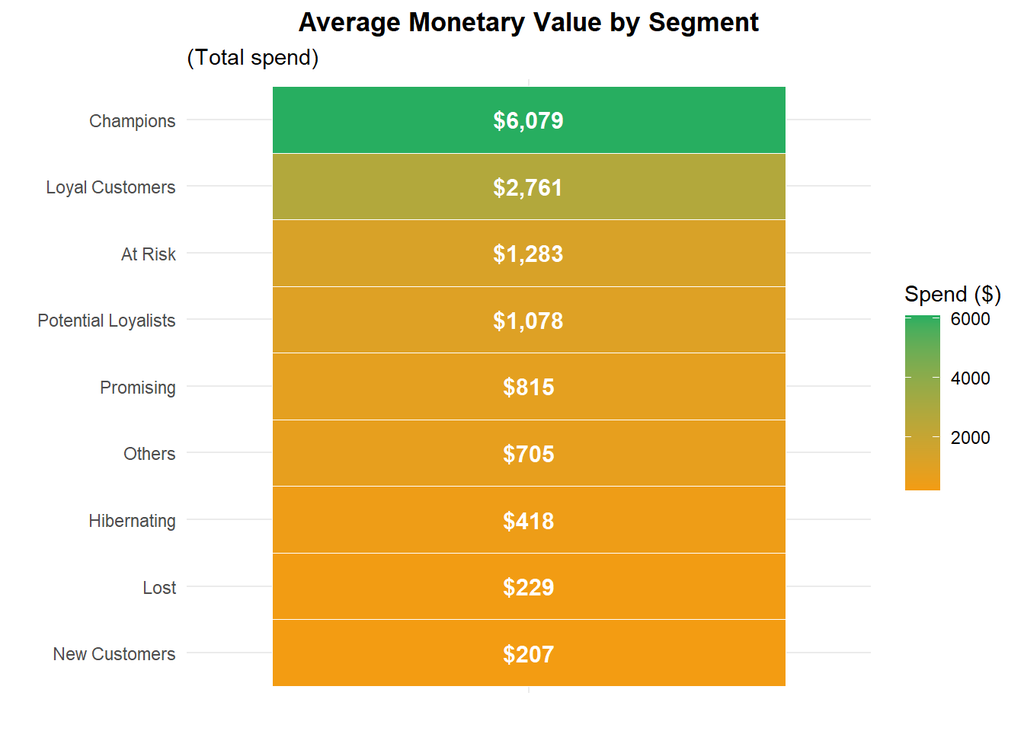

```r
#Monetary heatmap
seg_monetary <- rfm %>%
  group_by(Segment) %>%
  summarise(Monetary = mean(Monetary), .groups = "drop") %>%
  arrange(Monetary)

mgr <- ggplot(seg_monetary, aes(x = "", y = reorder(Segment, Monetary), fill = Monetary)) +
  geom_tile(color = "white", width = 0.9) +
  geom_text(aes(label = scales::dollar(round(Monetary, 0))),
            color = "white", size = 4, fontface = "bold") +
  scale_fill_gradient(low = "#f39c12", high = "#27ae60") +  #from orange to green
  labs(
    title = "Average Monetary Value by Segment",
    subtitle = "(Total spend)",
    x = "",
    y = "",
    fill = "Spend ($)"
  ) +
  theme_minimal() +
  theme(
    axis.text.x = element_blank(),
    plot.title = element_text(hjust = 0.5, face = "bold")
  )
mgr
```

##3. General scatter plots / Диаграма рассеяния

```r
library(scales)
summary(rfm$Frequency)
```

```
##    Min. 1st Qu.  Median    Mean 3rd Qu.    Max.
##   1.000   1.000   2.000   4.272   5.000 209.000
```

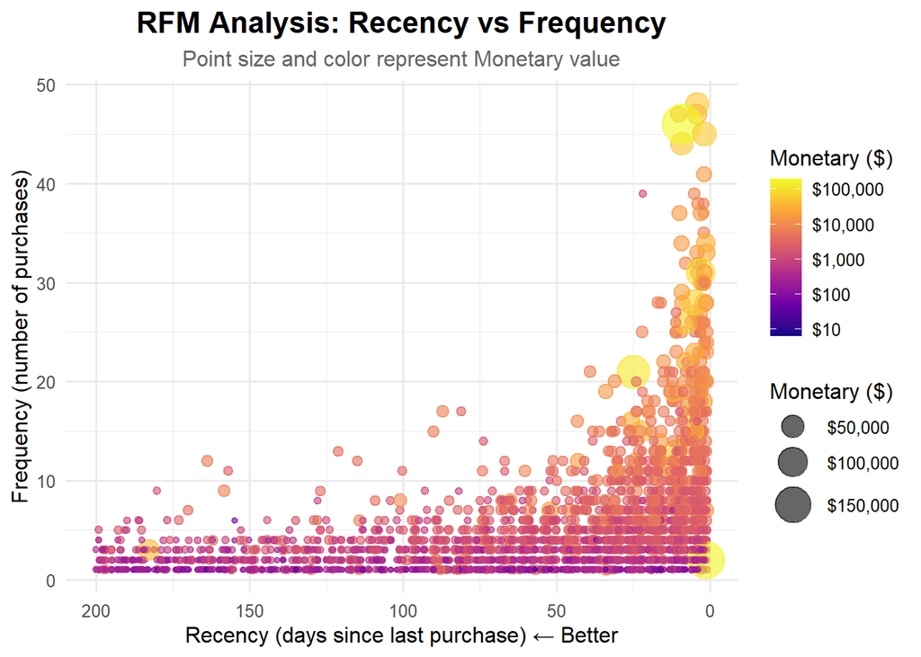

```r
rfm2 <- rfm %>% filter(Frequency < 50) %>% filter(Recency < 200) #exclude outliers beyond confidence intervals of 97% to ensure better trend visualisation / исключаем выбросы для лучшей визуализации

#scatter plot
scgr2 <- ggplot(rfm2, aes(x = Recency, y = Frequency, color = Monetary, size = Monetary)) +
  geom_point(alpha = 0.6) +
  scale_color_viridis_c(trans = "log10", labels = dollar, option = "plasma") +
  scale_size_continuous(range = c(1, 10), labels = dollar) +
  scale_x_reverse() +
  labs(
    title = "RFM Analysis: Recency vs Frequency",
    subtitle = "Point size and color represent Monetary value",
    x = "Recency (days since last purchase) ← Better",
    y = "Frequency (number of purchases)",
    color = "Monetary ($)",
    size = "Monetary ($)") +
  theme_minimal(base_size = 12) +
  theme(
    plot.title = element_text(face = "bold", size = 16, hjust = 0.5),
    plot.subtitle = element_text(size = 12, hjust = 0.5, color = "gray40"),
    legend.position = "right")
scgr2
```

##4. Scatter plot by segments / Диаграма рассеяния по сегментам

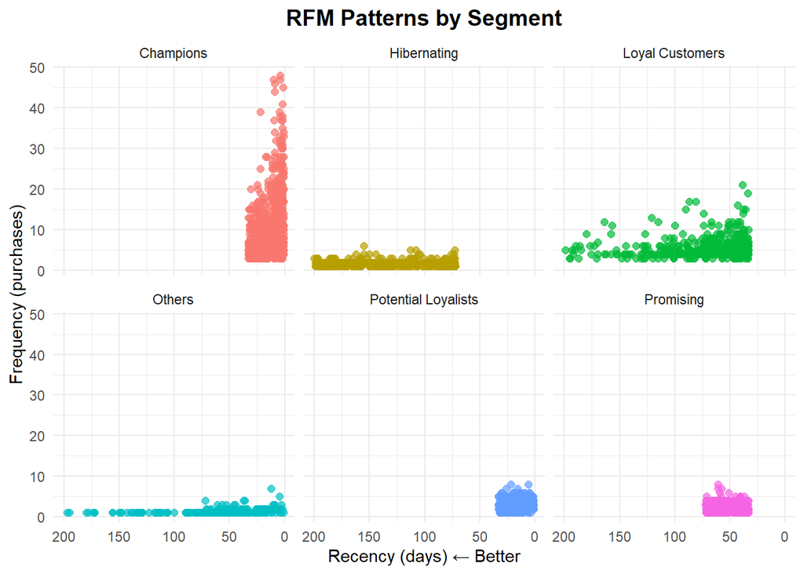

```r
top_segments <- rfm2 %>%
  count(Segment, sort = TRUE) %>%
  head(6) %>%
  pull(Segment) #leave only top 6 segments / оставляем только топ 6

rfm_top <- rfm2 %>%
  filter(Segment %in% top_segments)

sgr <- ggplot(rfm_top, aes(x = Recency, y = Frequency, color = Segment)) +
  geom_point(alpha = 0.7, size = 2) +
  scale_x_reverse() +
  facet_wrap(~Segment, ncol = 3) +
  labs(
    title = "RFM Patterns by Segment",
    x = "Recency (days) ← Better",
    y = "Frequency (purchases)") +
  theme_minimal(base_size = 11) +
  theme(
    plot.title = element_text(face = "bold", size = 14, hjust = 0.5),
    legend.position = "none")
sgr
```

#PART 5. Conclusions and recommendations for business / Выводы и рекоммендациии

```r
#segment statistics
seg_analysis <- rfm %>%
  group_by(Segment) %>%
  summarise(
    Count = n(),
    Avg_Recency = mean(Recency),
    Avg_Frequency = mean(Frequency),
    Avg_Monetary = mean(Monetary),
    Total_Revenue = sum(Monetary),
    .groups = "drop") %>%
  mutate(
    Percent_Customers = Count / sum(Count) * 100,
    Percent_Revenue = Total_Revenue / sum(Total_Revenue) * 100) %>%
  arrange(desc(Total_Revenue))

seg_analysis
```

```
## # A tibble: 9 × 8
##   Segment             Count Avg_Recency Avg_Frequency Avg_Monetary Total_Revenue
##   <chr>               <int>       <dbl>         <dbl>        <dbl>         <dbl>
## 1 Champions             946        13.0         11.2         6079.      5750763.
## 2 Loyal Customers       416        80.4          6.04        2761.      1148609.
## 3 Potential Loyalists   559        16.9          2.73        1078.       602367.
## 4 At Risk               293       150.           2.81        1283.       375826.
## 5 Others                429        83.3          1.22         705.       302365.
## 6 Promising             366        51.8          2.36         815.       298232.
## 7 Hibernating           704       202.           1.56         418.       294054.
## 8 Lost                  455       229.           1            229.       104086.
## 9 New Customers         170        18.7          1.01         207.        35107.
## # ℹ 2 more variables: Percent_Customers <dbl>, Percent_Revenue <dbl>
```

## Key Findings

- **Who they are:** Consistent repeat buyers
- **Average spend:** $2761 per customer
- **Purchase frequency:** 6 orders per customer

- **Who they are:** Previously high-value customers who haven’t purchased in 150+ days
- **Average historical spend:** $1283
- **What happened:** Likely switched to competitor or lost interest

- **Who they are:** One-time buyers from 230+ days ago
- **Average spend:** $229 (very low)
- **Reality check:** Not worth investing marketing budget

**Business Impact:** - **Recommendation:** Exclude from email campaigns (save costs)

## Marketing recommendations

[output not shown]